# IODS course project

Senka Drobac

# About the project

Introduction to Open Data Science 2018 is a course at University of Helsinki.

My GitHub repository: [link](https://github.com/sdrobac/IODS-project)

# Week 2 - Regression and model validation

This chapter describes the work done this week, the results and it’s interpretations.

## 1. Brief dataset description

The data we are working on was collected during course: Johdatus yhteiskuntatilastotieteeseen, syksy 2014 (Introduction to Social Statistics, fall 2014 - in Finnish), international survey of Approaches to Learning, made possible by Teachers’ Academy funding for KV in 2013-2015. Data are used for teaching purposes from 1/2017 on with a course Introduction to Open Data Science.

Data has totaly 166 observations and 7 variables: gender, age, attitude, deep, stra, surf and points.

```r
testData <- read.table("data/learning2014.txt")
dim(testData)
```

```
## [1] 166   7
```

```r
colnames(testData)
```

```
## [1] "gender"   "age"      "attitude" "deep"     "stra"     "surf"
## [7] "points"
```

## 2. Data overview

Summaries of the data variables:

- **gender** - Gender: M (Male), F (Female)
- **age** - Age (in years) derived from the date of birth
- **attitude** - Global attitude toward statistics
- **deep** - Average score on questions related to deep learning
- **stra** - Average score on questions related to strategic learning
- **surf** - Average score on questions related to surface learning
- **points** - Exam points

Graphical represtentaion of the data:

```r
library(GGally)
```

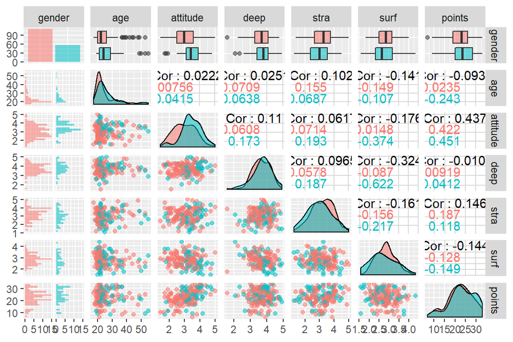

```r
library(ggplot2)
p <- ggpairs(testData, mapping = aes(col=gender, alpha = 0.3), lower = list(combo = wrap("facethist", bins = 20)))
p
```

## 3. Regression model

We are trying to fit a regression model where exam *points* is the target variable and explanatory variables are the three most significant variables in relation to the target: *attitude*, *stra* and *surf* .

```r
my_model <- lm(points ~ attitude + stra + surf, data = testData)
summary(my_model)
```

```
##
## Call:
## lm(formula = points ~ attitude + stra + surf, data = testData)
##
## Residuals:
##      Min       1Q   Median       3Q      Max
## -17.1550  -3.4346   0.5156   3.6401  10.8952
##
## Coefficients:
##             Estimate Std. Error t value Pr(>|t|)
## (Intercept)  11.0171     3.6837   2.991  0.00322 **
## attitude      3.3952     0.5741   5.913 1.93e-08 ***
## stra          0.8531     0.5416   1.575  0.11716
## surf         -0.5861     0.8014  -0.731  0.46563
## ---
## Signif. codes:  0 '***' 0.001 '**' 0.01 '*' 0.05 '.' 0.1 ' ' 1
##
## Residual standard error: 5.296 on 162 degrees of freedom
## Multiple R-squared:  0.2074, Adjusted R-squared:  0.1927
## F-statistic: 14.13 on 3 and 162 DF,  p-value: 3.156e-08
```

The summary of the model shows us residuals, as well as estimated parameters of the linear function, which gives us regression equation describing the relationship between exam *points* and *attitude*, *stra* and *surf* :

$points = \alpha + \beta_1 \cdot attitude + \beta_2 \cdot stra + \beta_3 \cdot surf$

and the estimates are:

$\alpha$ = 11.0171  
$\beta_1$ = 3.3952  
$\beta_2$ = 0.8531  
$\beta_3$ = -0.5861

Which gives us the regression equation:  
$points = 11.0171 + 3.3952 \cdot attitude + 0.8531 \cdot stra - 0.5861 \cdot surf$

## 4. Results interpretation

Intercept ($\alpha$) is a *points’* value when all of the 3 variables are equal to 0. That is the value where linear regression graph crosses the y-axis (the *points* axis). If *attitude* chages by one unit, exam *points* will change by 3.3952 units, given that the other variables do not change. Similarly, the same principle is valid for other variables and their parameters (if *stra* changes by one unit, *points* will change by 0.8531 units and if *surf* changes by one unit, *points* will change by -0.5861 units, given that other variables don’t change).

Multiple R-squared of the model is: 0.2074, that is 20.74%. This measure tells us how close the data are to the fitted regression line. The value being around 20% indicates that the model explains some of the variability of the response data around its mean.

## 5. Diagnostic plots

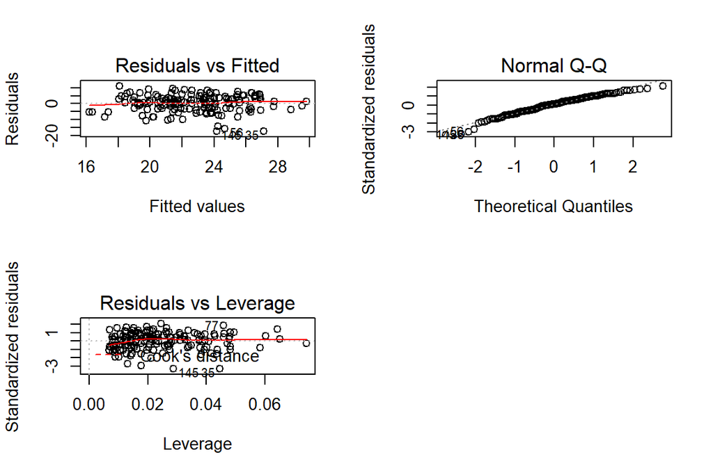

```r
par(mfrow = c(2,2))
plot(my_model, which=c(1,2,5))
```

**Residuals vs Fitted plot** shows that residuals don’t have a non-linear pattern which means that linear model is good for analysis of our data.

**Normal QQ-plot** shows us that the residuals were normally distributed, which is also a sign of a good model.

**Residuals vs Leverage plot** helps to find influential outliners. In our plot I don’t see any influential outliners. We can’t even see Cook’s distance lines (a red dashed line) because all cases are well inside of the Cook’s distance lines.

These three plots show us that there isn’t anything problematic in our model and that it is a good representation of our data.

# Week 3 - Logistic regression

The dataset that we are using here is joined data set that contains student information, including student alcohol consumption. General information about the data set can be found [here](https://archive.ics.uci.edu/ml/datasets/Student+Performance).The following adjustments have been made:

- The variables not used for joining the two data have been combined by averaging (including the grade variables)
- ‘alc_use’ is the average of ‘Dalc’ and ‘Walc’
- ‘high_use’ is TRUE if ‘alc_use’ is higher than 2 and FALSE otherwise

Dataset variables:

```r
colnames(alc)
```

```
##  [1] "school"     "sex"        "age"        "address"    "famsize"
##  [6] "Pstatus"    "Medu"       "Fedu"       "Mjob"       "Fjob"
## [11] "reason"     "nursery"    "internet"   "guardian"   "traveltime"
## [16] "studytime"  "failures"   "schoolsup"  "famsup"     "paid"
## [21] "activities" "higher"     "romantic"   "famrel"     "freetime"
## [26] "goout"      "Dalc"       "Walc"       "health"     "absences"
## [31] "G1"         "G2"         "G3"         "alc_use"    "high_use"
```

## Hypothesis

The purpose of the analysis is to study the relationships between high/low alcohol consumption and some of the other variables in the data. Here I am choosing 4 variables and my hypothesis about their relationships with alcohol consumption.

1. **Pstatus** - parent’s cohabitation status (binary: ‘T’ - living together or ‘A’ - apart)  
   I’m interested to see if children of parents who live together drink less than those of parents living apart.  
   Hypothesis: Parents living apart → Higer alchocol consumption
2. **famrel** - quality of family relationships (numeric: from 1 - very bad to 5 - excellent)  
   Hypothesis: Bad quiality → Higer alchocol consumption
3. **freetime** - free time after school (numeric: from 1 - very low to 5 - very high)  
   Hypothesis: More freetime → Higer alchocol consumption
4. **goout** - going out with friends (numeric: from 1 - very low to 5 - very high)  
   Hypothesis: Going out with friends more often → Higer alchocol consumption

## Distributions

### Distributions of the chosen variables

First, here are distributions of the chosen variables:

```
## Observations: 382
## Variables: 5
## $ Pstatus  <fct> A, T, T, T, T, T, T, A, A, T, T, T, T, T, A, T, T, T,...
## $ famrel   <int> 4, 5, 4, 3, 4, 5, 4, 4, 4, 5, 3, 5, 4, 5, 4, 4, 3, 5,...
## $ freetime <int> 3, 3, 3, 2, 3, 4, 4, 1, 2, 5, 3, 2, 3, 4, 5, 4, 2, 3,...
## $ goout    <int> 4, 3, 2, 2, 2, 2, 4, 4, 2, 1, 3, 2, 3, 3, 2, 4, 3, 2,...
## $ high_use <lgl> FALSE, FALSE, TRUE, FALSE, FALSE, FALSE, FALSE, FALSE...
```

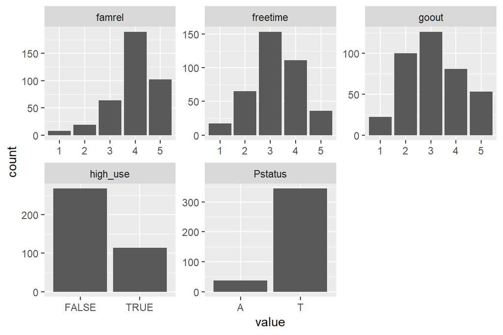

### Varibales relationships with high alcohol consumption:

Now we’ll explore varibales relationships with high alcohol consumption:

1. Parent’s cohabitation status and high alchocol use

```
## # A tibble: 4 x 4
## # Groups:   Pstatus [2]
##   Pstatus high_use     n  freq
##   <fct>   <lgl>    <int> <dbl>
## 1 A       FALSE       26 0.684
## 2 A       TRUE        12 0.316
## 3 T       FALSE      242 0.703
## 4 T       TRUE       102 0.297
```

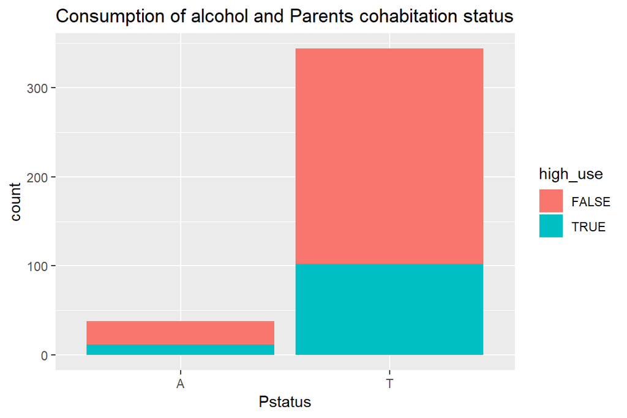

Only 31.6% of students whose parents live apart and 29.7% of those whose parents live together have high alchocol consumption. The differnce between these two groups is not very big, thus my hypothesis was wrong.

2. Quality of family relationships and high alchocol use

```
## # A tibble: 10 x 4
## # Groups:   famrel [5]
##    famrel high_use     n  freq
##     <int> <lgl>    <int> <dbl>
##  1      1 FALSE        6 0.75
##  2      1 TRUE         2 0.25
##  3      2 FALSE       10 0.526
##  4      2 TRUE         9 0.474
##  5      3 FALSE       39 0.609
##  6      3 TRUE        25 0.391
##  7      4 FALSE      135 0.714
##  8      4 TRUE        54 0.286
##  9      5 FALSE       78 0.765
## 10      5 TRUE        24 0.235
```

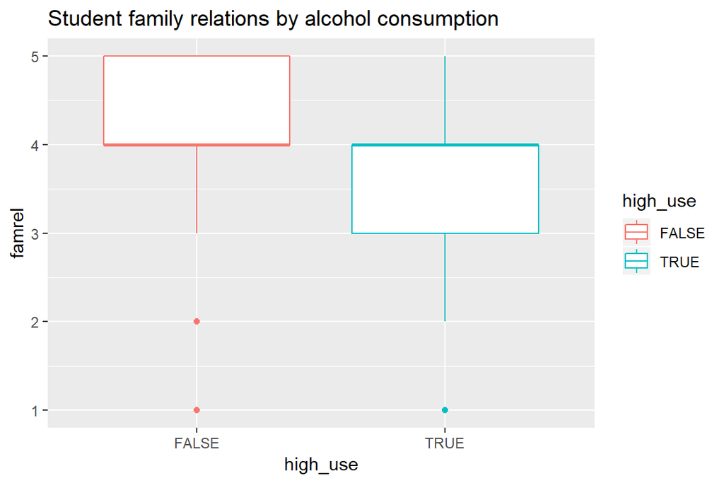

As assumed, students with better family relationships have smaller alchocol consumption.

3. Free time after school and high alchocol use

```
## # A tibble: 10 x 4
## # Groups:   freetime [5]
##    freetime high_use     n  freq
##       <int> <lgl>    <int> <dbl>
##  1        1 FALSE       15 0.882
##  2        1 TRUE         2 0.118
##  3        2 FALSE       49 0.754
##  4        2 TRUE        16 0.246
##  5        3 FALSE      113 0.739
##  6        3 TRUE        40 0.261
##  7        4 FALSE       70 0.631
##  8        4 TRUE        41 0.369
##  9        5 FALSE       21 0.583
## 10        5 TRUE        15 0.417
```

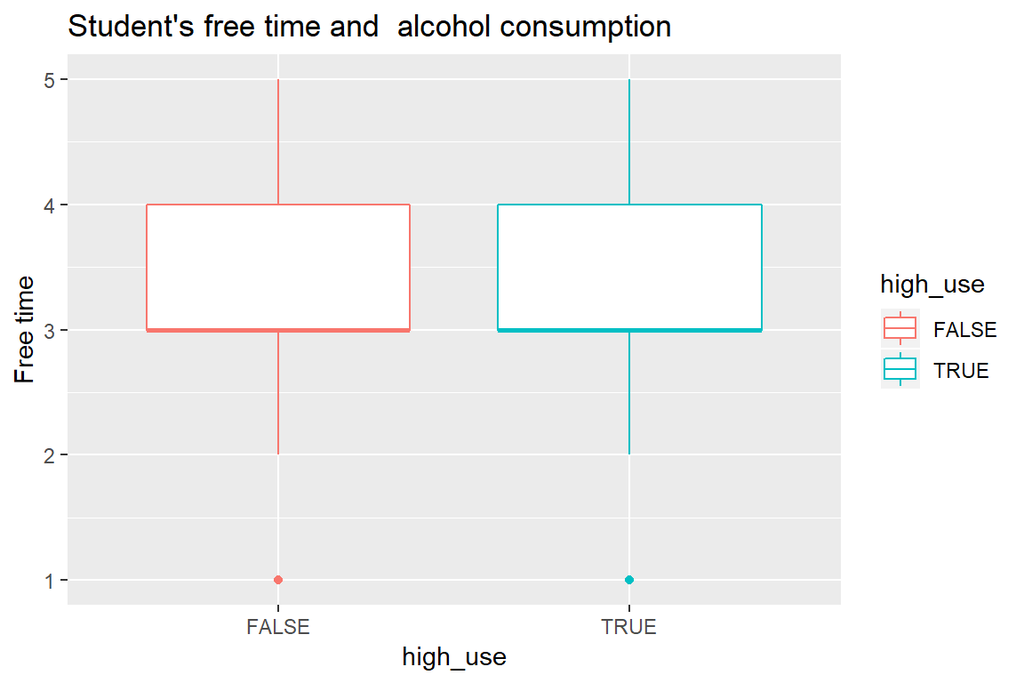

4. Going out with friends and high alchocol use

```
## # A tibble: 10 x 4
## # Groups:   goout [5]
##    goout high_use     n  freq
##    <int> <lgl>    <int> <dbl>
##  1     1 FALSE       19 0.864
##  2     1 TRUE         3 0.136
##  3     2 FALSE       84 0.84
##  4     2 TRUE        16 0.16
##  5     3 FALSE      103 0.817
##  6     3 TRUE        23 0.183
##  7     4 FALSE       41 0.506
##  8     4 TRUE        40 0.494
##  9     5 FALSE       21 0.396
## 10     5 TRUE        32 0.604
```

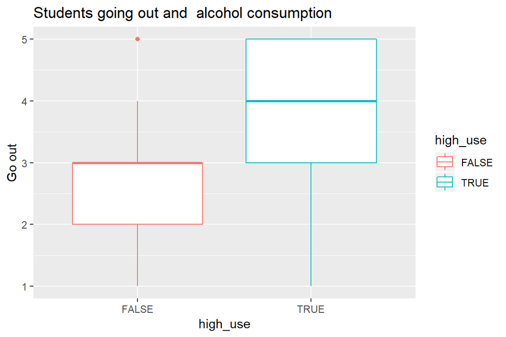

Students that go out with thier firends a lot, have higher alchocol consumption. This confirms the hypothesis.

## Logistic regression

#### The model

Now we’ll use logistic regression to statistically explore the relationship between the chosen variables and the binary high/low alcohol consumption variable as the target variable.

Here is the summary of the fitted model:

```r
# print out a summary of the model
summary(m)
```

```
##
## Call:
## glm(formula = high_use ~ Pstatus + famrel + freetime + goout,
##     family = "binomial", data = alc)
##
## Deviance Residuals:
##     Min       1Q   Median       3Q      Max
## -1.6507  -0.7947  -0.5693   1.0025   2.4052
##
## Coefficients:
##             Estimate Std. Error z value Pr(>|z|)
## (Intercept)  -2.2734     0.7423  -3.063  0.00219 **
## PstatusT     -0.1093     0.4018  -0.272  0.78557
## famrel       -0.3875     0.1359  -2.852  0.00435 **
## freetime      0.1751     0.1334   1.312  0.18949
## goout         0.7473     0.1220   6.123 9.17e-10 ***
## ---
## Signif. codes:  0 '***' 0.001 '**' 0.01 '*' 0.05 '.' 0.1 ' ' 1
##
## (Dispersion parameter for binomial family taken to be 1)
##
##     Null deviance: 465.68  on 381  degrees of freedom
## Residual deviance: 406.34  on 377  degrees of freedom
## AIC: 416.34
##
## Number of Fisher Scoring iterations: 4
```

The summary shows that Pstatus and freetime don’t have statistical relationship with target, which confirms the analysis above.

#### Coefficients of the model

Here we present the coefficients of the model as odds ratios and provide confidence intervals for them:

```
##                    OR      2.5 %    97.5 %
## (Intercept) 0.1029622 0.02316672 0.4298596
## PstatusT    0.8964576 0.41467616 2.0265025
## famrel      0.6787266 0.51825726 0.8845457
## freetime    1.1913437 0.91797013 1.5509857
## goout       2.1113265 1.67267689 2.7018310
```

Odds ratios are used to compare the relative odds of the occurrence of the outcome of interest (in this case high alcohol use), given exposure to the variables of interest.

We can see that exposure to famrel and PstatusT is associated with lower odds of outcome, while exposure to freetime and goout is associated with higher odds high alchocol use. Predictor PStatusT has the widest confidence interval.

## Predictive power of the model

According to the previous logistic regression model, only variables **famrel** and **goout** had a statistical relationship with high/low alcohol consumption. So here we create a new model, with only those two variables.

```r
m <- glm(high_use ~ famrel + goout, data = alc, family = "binomial")
summary(m)
```

```
##
## Call:
## glm(formula = high_use ~ famrel + goout, family = "binomial",
##     data = alc)
##
## Deviance Residuals:
##     Min       1Q   Median       3Q      Max
## -1.5448  -0.7518  -0.5252   0.9872   2.3530
##
## Coefficients:
##             Estimate Std. Error z value Pr(>|z|)
## (Intercept)  -2.0289     0.6148  -3.300 0.000966 ***
## famrel       -0.3667     0.1338  -2.740 0.006142 **
## goout         0.7922     0.1183   6.698 2.11e-11 ***
## ---
## Signif. codes:  0 '***' 0.001 '**' 0.01 '*' 0.05 '.' 0.1 ' ' 1
##
## (Dispersion parameter for binomial family taken to be 1)
##
##     Null deviance: 465.68  on 381  degrees of freedom
## Residual deviance: 408.12  on 379  degrees of freedom
## AIC: 414.12
##
## Number of Fisher Scoring iterations: 4
```

Here is a 2x2 cross tabulation of predictions versus the actual values and a graphic visualization of both the actual values and the predictions.

```
##         prediction
## high_use FALSE TRUE
##    FALSE   243   25
##    TRUE     68   46
```

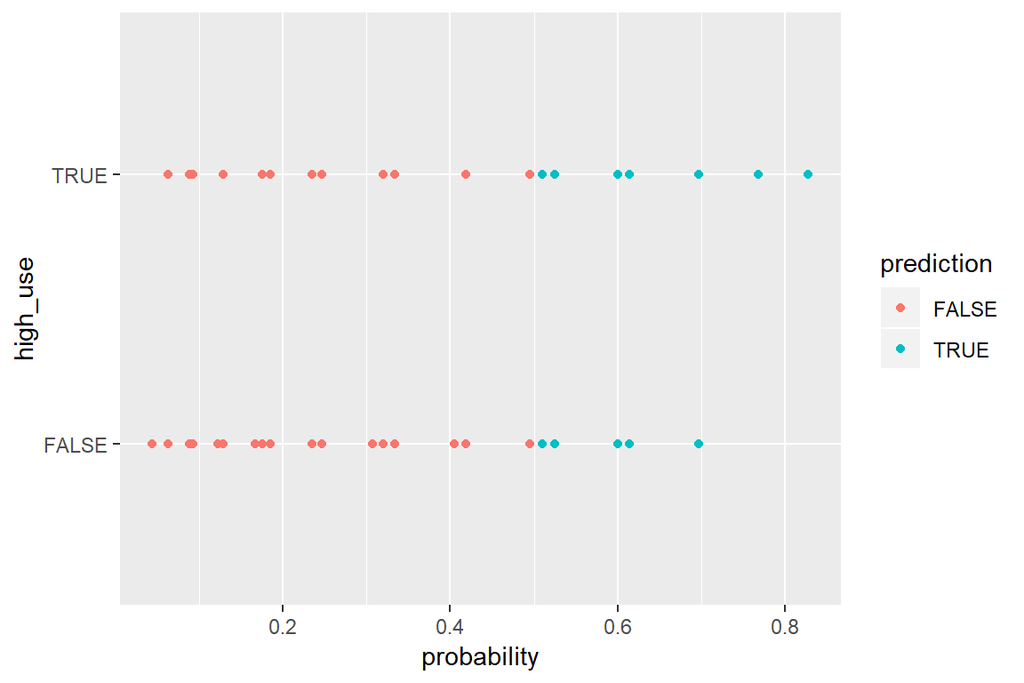

```
##         prediction
## high_use      FALSE       TRUE        Sum
##    FALSE 0.63612565 0.06544503 0.70157068
##    TRUE  0.17801047 0.12041885 0.29842932
##    Sum   0.81413613 0.18586387 1.00000000
```

Now we compute the total proportion of inaccurately classified individuals:

```
## [1] 0.2434555
```

## Bonus: Cross-validation

Here is error after a 10-fold cross-validation on my model:

```
## [1] 0.2486911
```

# Week 4 - Clustering and classification

## Dataset

This week we are using the Boston dataset from the MASS package. It contains housing values in suburbs of Boston. The Boston data frame has 506 rows and 14 columns. Details about the dataset could be found [here](https://stat.ethz.ch/R-manual/R-devel/library/MASS/html/Boston.html)

Descriptions of the variables:

| Variable | Description |
| --- | --- |
| crim | per capita crime rate by town. |
| zn | proportion of residential land zoned for lots over 25,000 sq.ft. |
| indus | proportion of non-retail business acres per town. |
| chas | Charles River dummy variable (= 1 if tract bounds river; 0 otherwise). |
| nox | nitrogen oxides concentration (parts per 10 million). |
| rm | average number of rooms per dwelling. |
| age | proportion of owner-occupied units built prior to 1940. |
| dis | weighted mean of distances to five Boston employment centres. |
| rad | index of accessibility to radial highways. |
| tax | full-value property-tax rate per $10,000. |
| ptratio | pupil-teacher ratio by town. |
| black | 1000(Bkâ0.63)^2 where Bk is the proportion of blacks by town. |
| lstat | lower status of the population (percent). |
| medv | median value of owner-occupied homes in $1000s. |

```r
# access the MASS package
library(MASS)
```

```r
library(dplyr)
library(ggplot2)
# install.packages('corrplot')
# install.packages('tidyverse')
library(corrplot)
# library(tidyverse)

# load the data
data("Boston")

# explore the dataset
str(Boston)
```

```
## 'data.frame':    506 obs. of  14 variables:
##  $ crim   : num  0.00632 0.02731 0.02729 0.03237 0.06905 ...
##  $ zn     : num  18 0 0 0 0 0 12.5 12.5 12.5 12.5 ...
##  $ indus  : num  2.31 7.07 7.07 2.18 2.18 2.18 7.87 7.87 7.87 7.87 ...
##  $ chas   : int  0 0 0 0 0 0 0 0 0 0 ...
##  $ nox    : num  0.538 0.469 0.469 0.458 0.458 0.458 0.524 0.524 0.524 0.524 ...
##  $ rm     : num  6.58 6.42 7.18 7 7.15 ...
##  $ age    : num  65.2 78.9 61.1 45.8 54.2 58.7 66.6 96.1 100 85.9 ...
##  $ dis    : num  4.09 4.97 4.97 6.06 6.06 ...
##  $ rad    : int  1 2 2 3 3 3 5 5 5 5 ...
##  $ tax    : num  296 242 242 222 222 222 311 311 311 311 ...
##  $ ptratio: num  15.3 17.8 17.8 18.7 18.7 18.7 15.2 15.2 15.2 15.2 ...
##  $ black  : num  397 397 393 395 397 ...
##  $ lstat  : num  4.98 9.14 4.03 2.94 5.33 ...
##  $ medv   : num  24 21.6 34.7 33.4 36.2 28.7 22.9 27.1 16.5 18.9 ...
```

```r
dim(Boston)
```

```
## [1] 506  14
```